# **Retail Sales Data Cleaning and Preparation**

**Brief Description of the Project:**

This project focuses on cleaning and preparing a retail sales dataset. The main objective is to ensure data quality by addressing missing values, duplicates, and outliers, as well as standardizing data types. The cleaned dataset is ready for future analysis and modeling tasks.

**Objectives:**

- Identify and handle data quality issues, such as missing values, duplicates, and outliers.
- Transform and standardize DataFrame columns for efficient analysis.
- Export the cleaned DataFrame for use in analytical and modeling tasks

## **1. Importing Libraries and Loading Datasets**

**Description**  
In this step, we set up the environment by importing necessary libraries and loading the datasets into Pandas DataFrames for cleaning and preparation. The initial rows of the dataset are displayed to confirm successful loading and identify the structure of the data.

```python
# Import necessary libraries
import pandas as pd  # Data manipulation
import matplotlib.pyplot as plt  # Visualization

# Define the base directory where datasets are stored
base_path = r"C:\\Users\\robin\\Desktop\\para limpiar"

# Load dataset into a DataFrame
features_df = pd.read_csv(base_path + r"\\Features data set.csv")

# Display the first rows of the 'features' DataFrame
print("Features DataFrame (First 5 Rows):")
print(features_df.head(), "\n")
```

```
Features DataFrame (First 5 Rows):
   Store        Date  Temperature  Fuel_Price  MarkDown1  MarkDown2  \
0      1  05/02/2010        42.31       2.572        NaN        NaN
1      1  12/02/2010        38.51       2.548        NaN        NaN
2      1  19/02/2010        39.93       2.514        NaN        NaN
3      1  26/02/2010        46.63       2.561        NaN        NaN
4      1  05/03/2010        46.50       2.625        NaN        NaN

   MarkDown3  MarkDown4  MarkDown5         CPI  Unemployment  IsHoliday
0        NaN        NaN        NaN  211.096358         8.106      False
1        NaN        NaN        NaN  211.242170         8.106       True
2        NaN        NaN        NaN  211.289143         8.106      False
3        NaN        NaN        NaN  211.319643         8.106      False
4        NaN        NaN        NaN  211.350143         8.106      False
```

**Key Insights**

## **2. Creating Backup Copies of the Original DataFrames**

**Description**  
Before making any changes to the datasets, it is essential to create backup copies of the original DataFrames. This ensures that the original data remains intact in case of errors during the cleaning process.

```python
# Create backup copy of the original DataFrame
features_df_backup = features_df.copy()

# Verify that the copies have been created correctly
print("Backup of Features DataFrame (First 5 Rows):")
print(features_df_backup.head(), "\n")  # Displays the first rows of features_df backup
```

```
Backup of Features DataFrame (First 5 Rows):
   Store        Date  Temperature  Fuel_Price  MarkDown1  MarkDown2  \
0      1  05/02/2010        42.31       2.572        NaN        NaN
1      1  12/02/2010        38.51       2.548        NaN        NaN
2      1  19/02/2010        39.93       2.514        NaN        NaN
3      1  26/02/2010        46.63       2.561        NaN        NaN
4      1  05/03/2010        46.50       2.625        NaN        NaN

   MarkDown3  MarkDown4  MarkDown5         CPI  Unemployment  IsHoliday
0        NaN        NaN        NaN  211.096358         8.106      False
1        NaN        NaN        NaN  211.242170         8.106       True
2        NaN        NaN        NaN  211.289143         8.106      False
3        NaN        NaN        NaN  211.319643         8.106      False
4        NaN        NaN        NaN  211.350143         8.106      False
```

**Key Insights**

- Backup copies of the original DataFrames have been successfully created.
- The `head()` method confirms that the backups contain the same data as the original DataFrame.
- These backups will act as a safeguard and allow us to revert to the original data if needed.

## **3. Checking for Missing Values, Duplicates, and Data Types**

**Description**  
To ensure data quality, we first identify missing values, duplicate rows, and review the data types of each column in the dataset. These issues can affect the integrity of the analysis and need to be addressed.

```python
# Check for missing values in each column
print("Missing Values per Column:")
print(features_df.isnull().sum())

# Key observations on missing values:
# - MarkDown columns (1-5) have a significant number of missing values, reducing their usefulness.
# - CPI and Unemployment columns also have missing values that require treatment to avoid bias.

# Check for duplicate rows in the DataFrame
print("\nNumber of Duplicate Rows:")
print(features_df.duplicated().sum())  # Displays the count of duplicate rows

# Observations:
# The DataFrame has no duplicate rows, ensuring each row represents unique data.

# Review data types of the columns
print("\nData Types of Features DataFrame:")
print(features_df.dtypes)
```

```
Missing Values per Column:
Store              0
Date               0
Temperature        0
Fuel_Price         0
MarkDown1       4158
MarkDown2       5269
MarkDown3       4577
MarkDown4       4726
MarkDown5       4140
CPI              585
Unemployment     585
IsHoliday          0
dtype: int64

Number of Duplicate Rows:
0

Data Types of Features DataFrame:
Store             int64
Date             object
Temperature     float64
Fuel_Price      float64
MarkDown1       float64
MarkDown2       float64
MarkDown3       float64
MarkDown4       float64
MarkDown5       float64
CPI             float64
Unemployment    float64
IsHoliday          bool
dtype: object
```

**Key Insights**

## **4. Reviewing Data Types of the Dataset**

**Description**  
To ensure the dataset is ready for analysis, we check the data types of each column. This helps identify columns that might need transformation or type correction for accurate processing.

```python
# Review data types of the 'features' DataFrame
print("Data Types of Features DataFrame:")
print(features_df.dtypes)
```

[output not shown]

**Key Insights**

## **5. Converting the 'Date' Column to Datetime Format**

**Description**  
To facilitate date-based analysis, the `Date` column needs to be converted from an object to a **datetime** format. This ensures that operations such as sorting, filtering, and aggregating data by date can be performed accurately.

```python
# Convert the 'Date' column to datetime format
features_df['Date'] = pd.to_datetime(features_df['Date'], dayfirst=True)

# Confirm the change by displaying the first 5 rows of the 'Date' column
print("First 5 rows of the 'Date' column after conversion:")
print(features_df['Date'].head())
```

```
First 5 rows of the 'Date' column after conversion:
0   2010-02-05
1   2010-02-12
2   2010-02-19
3   2010-02-26
4   2010-03-05
Name: Date, dtype: datetime64[ns]
```

**Key Insights**

- The `Date` column has been successfully converted to **datetime64[ns]**.
- Using `dayfirst=True` ensures the correct interpretation of the date format as DD/MM/YYYY.
- The transformation prepares the column for time-based operations, which are essential for further analysis.

## **6. Checking Percentage of NaN Values in MarkDown Columns**

**Description**  
To make informed decisions about data cleaning, we analyze the proportion of missing (`NaN`) and non-missing values in the `MarkDown1-5` columns. This helps us determine whether to impute or remove these columns based on their data quality.

```python
# List of MarkDown columns to analyze
markdown_cols = ['MarkDown1', 'MarkDown2', 'MarkDown3', 'MarkDown4', 'MarkDown5']

# Calculate and display the percentage of NaN and non-NaN values for each column
for col in markdown_cols:
    total = len(features_df[col])  # Total number of rows
    nan_count = features_df[col].isnull().sum()  # Count of NaN values
    non_nan_count = total - nan_count  # Count of non-NaN values

    print(f"{col}:")
    print(f"   NaN: {nan_count / total * 100:.2f}%")  # Percentage of NaN values
    print(f"   Non-NaN: {non_nan_count / total * 100:.2f}%\n")  # Percentage of non-NaN values
```

```
MarkDown1:
   NaN: 50.77%
   Non-NaN: 49.23%

MarkDown2:
   NaN: 64.33%
   Non-NaN: 35.67%

MarkDown3:
   NaN: 55.89%
   Non-NaN: 44.11%

MarkDown4:
   NaN: 57.70%
   Non-NaN: 42.30%

MarkDown5:
   NaN: 50.55%
   Non-NaN: 49.45%
```

**Key Insights**

- `MarkDown1`: **50.77%** of values are missing.
- `MarkDown2`: **64.33%** of values are missing (highest percentage).
- `MarkDown3`: **55.89%** of values are missing.
- `MarkDown4`: **57.70%** of values are missing.
- `MarkDown5`: **50.55%** of values are missing.
- Columns like `MarkDown2`, with more than 60% missing values, may need to be removed.
- Other columns with slightly lower percentages could be imputed based on their relevance to the analysis.

## **7. Replacing NaN Values with 0 in MarkDown Columns**

**Description**  
To handle missing values (`NaN`) in the `MarkDown1-5` columns, we replace them with `0`. This ensures consistency in the dataset and avoids issues during numerical operations.

```python
# List of MarkDown columns to analyze
markdown_cols = ['MarkDown1', 'MarkDown2', 'MarkDown3', 'MarkDown4', 'MarkDown5']

# Replace NaN values with 0 in MarkDown columns
features_df[markdown_cols] = features_df[markdown_cols].fillna(0)

# Verify the change: Check if there are no NaN values remaining
print("Verifying that NaN values have been replaced with 0:")
print(features_df[markdown_cols].isnull().sum())  # Should return 0 for all columns

# Confirm no NaN values remain: Final verification step
print("\nAll NaN values successfully replaced (True means successful):")
print(features_df[markdown_cols].isnull().sum().sum() == 0)  # True if no NaN values
```

```
Verifying that NaN values have been replaced with 0:
MarkDown1    0
MarkDown2    0
MarkDown3    0
MarkDown4    0
MarkDown5    0
dtype: int64

All NaN values successfully replaced (True means successful):
True
```

**Key Insights**

- Missing values in `MarkDown1-5` have been successfully replaced with `0`.
- Verification confirms that no `NaN` values remain in these columns.
- These columns are now clean and ready for further analysis.

## **8. Cleaning 'Fuel_Price' and 'Temperature' Columns**

### 8.1 Fuel_Price

**Description**  
To ensure data integrity in the `Fuel_Price` and `Temperature` columns, we first analyze their statistics and distributions. This step helps identify potential outliers, inconsistencies, or invalid values.

```
Descriptive statistics for 'Fuel_Price':
count    8190.000000
mean        3.405992
std         0.431337
min         2.472000
25%         3.041000
50%         3.513000
75%         3.743000
max         4.468000
Name: Fuel_Price, dtype: float64
```

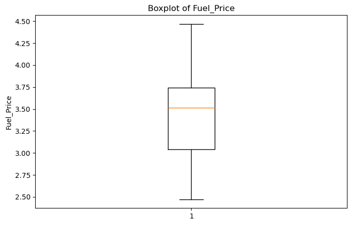

```python
# Step 1: Display descriptive statistics for 'Fuel_Price' to identify data range and potential outliers
print("Descriptive statistics for 'Fuel_Price':")
print(features_df['Fuel_Price'].describe())

# Step 2: Visualize the distribution of 'Fuel_Price' to highlight outliers
import matplotlib.pyplot as plt

plt.figure(figsize=(8, 5))
plt.boxplot(features_df['Fuel_Price'])
plt.title('Boxplot of Fuel_Price')
plt.ylabel('Fuel_Price')
plt.show()
```

**Key Insights**

## 8.2 Temperature

```
Descriptive statistics for 'Temperature':
count    8190.000000
mean       59.356198
std        18.678607
min        -7.290000
25%        45.902500
50%        60.710000
75%        73.880000
max       101.950000
Name: Temperature, dtype: float64
```

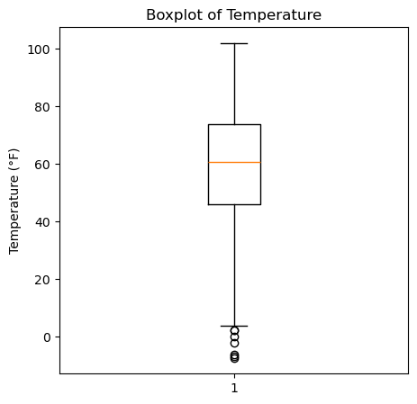

```python
# Step 1: Display descriptive statistics for 'Temperature' to identify data range and potential outliers
print("Descriptive statistics for 'Temperature':")
print(features_df['Temperature'].describe())

# Step 2: Visualize the distribution of 'Temperature' to highlight outliers
import matplotlib.pyplot as plt

plt.figure(figsize=(5, 5))
plt.boxplot(features_df['Temperature'])
plt.title("Boxplot of Temperature")
plt.ylabel("Temperature (°F)")
plt.show()
```

**Description** The `Temperature` column contains outliers identified using a boxplot and the Interquartile Range (IQR) calculation. These outliers fall outside the expected range and can negatively impact further analysis if not handled appropriately.

[output not shown]

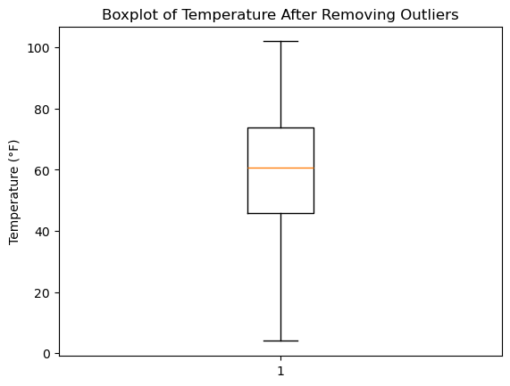

```python
# Calculate the lower and upper bounds of the interquartile range (IQR).
q1 = features_df['Temperature'].quantile(0.25)
q3 = features_df['Temperature'].quantile(0.75)
iqr = q3 - q1
lower_bound = q1 - 1.5 * iqr
upper_bound = q3 + 1.5 * iqr

print(f"Lower Bound: {lower_bound}, Upper Bound: {upper_bound}")

# Filter rows outside the expected range.
features_df = features_df[(features_df['Temperature'] >= lower_bound) & (features_df['Temperature'] <= upper_bound)]

# Verify that the outliers have been removed.
print(features_df['Temperature'].describe())

# Visualize the boxplot after cleaning.
plt.boxplot(features_df['Temperature'])
plt.title("Boxplot of Temperature After Removing Outliers")
plt.ylabel("Temperature (°F)")
plt.show()
```

**Key Insights**

## **9. Cleaning of the 'Store' Column**

**Description** The 'Store' column contains unique identifiers for stores and is critical for distinguishing data points. This step ensures that the identifiers are accurate and consistent across the dataset by checking for duplicates, the range of values, and general statistics.

```
45
8138
count    8183.000000
mean       23.011243
std        12.987156
min         1.000000
25%        12.000000
50%        23.000000
75%        34.000000
max        45.000000
Name: Store, dtype: float64
0
count    8183.000000
mean      173.187858
std        38.389357
min       126.064000
25%       132.653774
50%       182.716838
75%       212.815188
max       228.976456
Name: CPI, dtype: float64
```

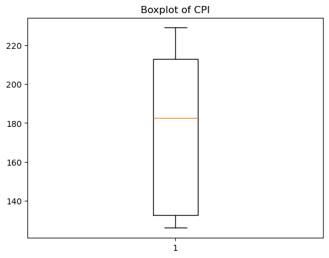

```python
# Count how many unique store identifiers exist in the 'Store' column.
print(features_df['Store'].nunique())

# Count how many rows have duplicate values in the 'Store' column.
print(features_df.duplicated(subset=['Store']).sum())

# Generate a statistical summary of the 'Store' column to review the range of identifiers.
print(features_df['Store'].describe())

# Fill missing values in the 'CPI' column with the column's median to ensure consistency and avoid skewing the data.
features_df['CPI'] = features_df['CPI'].fillna(features_df['CPI'].median())

# Check for any remaining missing values in the 'CPI' column to confirm that all NaN values have been filled.
print(features_df['CPI'].isnull().sum())

# Generate descriptive statistics for the 'CPI' column to analyze its distribution, central tendency, and variability.
print(features_df['CPI'].describe())

# Create a boxplot to visualize the distribution of the 'CPI' column and identify potential outliers.
import matplotlib.pyplot as plt
plt.boxplot(features_df['CPI'])
plt.title('Boxplot of CPI')
plt.show()
```

**Key Insights**

- **Store Analysis:**
  - **Unique Identifiers:** 45 unique store IDs (1 to 45).
  - **Duplicate Rows:** 8138 rows with duplicate store IDs (expected due to multiple records per store).
- **CPI Column:**
  - **Missing Values Filled:** NaN values in the 'CPI' column were replaced with the median.
  - **Post-Filling Check:** No remaining missing values (0 NaN).
  - **Statistical Summary:** Distribution of CPI values is consistent and within a reasonable range.
- **Visualization:**
  - **Boxplot:** No significant outliers detected in the 'CPI' column, indicating data cons---istency.

## **10. Cleaning of the ' Unemployment' Column**

**Description**  
The following code performs data cleaning and outlier detection for the 'Unemployment' column. The process involves identifying and handling missing values, visualizing the data, and applying interquartile range (IQR) techniques to detect and remove outliers. The goal is to ensure the data is accurate, consistent, and ready for analysis.

```
Missing values in 'Unemployment':
585

Descriptive statistics for 'Unemployment':
count    7598.000000
mean        7.827682
std         1.877575
min         3.684000
25%         6.634000
50%         7.806000
75%         8.567000
max        14.313000
Name: Unemployment, dtype: float64

Valid values: 7598 (92.85%)
NaN values: 585 (7.15%)

NaN values after filling:
0
```

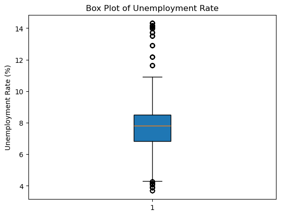

```
Lower Bound: 4.300999999999999, Upper Bound: 11.053

Detected Outliers:
      Store       Date  Temperature  Fuel_Price  MarkDown1  MarkDown2  \
672       4 2012-07-06        80.37       3.187    9789.03      90.00
673       4 2012-07-13        76.86       3.224   11075.38     151.00
674       4 2012-07-20        79.14       3.263    4799.23      47.55
675       4 2012-07-27        81.06       3.356    7011.68      68.70
676       4 2012-08-03        83.86       3.374   29127.20      42.27
...     ...        ...          ...         ...        ...        ...
7262     40 2013-03-29        34.60       3.796    4709.35       0.00
7263     40 2013-04-05        35.59       3.772   14110.29    5571.32
7264     40 2013-04-12        39.15       3.723    4934.33    3183.26
7265     40 2013-04-19        45.17       3.678    2322.79       1.59
7266     40 2013-04-26        44.43       3.626    1565.70       0.00

      MarkDown3  MarkDown4  MarkDown5         CPI  Unemployment  IsHoliday
672      157.62   10671.47    3864.91  130.719633         4.077      False
673       17.27    3810.25    4766.88  130.683000         4.077      False
674       30.56     634.78    4648.91  130.701290         4.077      False
675        4.26   13565.83    3841.61  130.719581         4.077      False
676       58.34   22663.73   10925.99  130.737871         4.077      False
...         ...        ...        ...         ...           ...        ...
7262     432.01      12.00    3696.08  138.991194         3.932      False
7263     189.13     785.63    3892.09  139.056903         3.684      False
7264      16.53     351.45    2203.32  139.122613         3.684      False
7265      20.10     133.68    1429.80  139.122613         3.684      False
7266      42.99      44.44    1051.49  139.122613         3.684      False

[559 rows x 12 columns]

Descriptive statistics after removing outliers:
count    7624.000000
mean        7.637358
std         1.241948
min         4.308000
25%         6.855000
50%         7.806000
75%         8.433000
max        10.926000
Name: Unemployment, dtype: float64
```

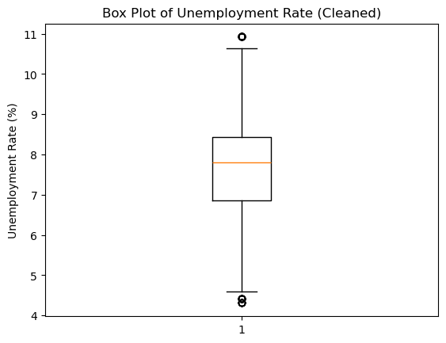

```python
# Step 1: Check for missing values
# This checks for NaN values in the 'Unemployment' column to identify missing data.
print("Missing values in 'Unemployment':")
print(features_df['Unemployment'].isnull().sum())

# Step 2: Descriptive statistics
# Generates summary statistics to understand the distribution and detect potential outliers.
print("\nDescriptive statistics for 'Unemployment':")
print(features_df['Unemployment'].describe())

# Step 3: Calculate percentage of missing data
# Calculates the percentage of missing and valid data to assess the extent of missing values.
total_rows = len(features_df)
nan_count = features_df['Unemployment'].isnull().sum()
valid_count = total_rows - nan_count

nan_percentage = (nan_count / total_rows) * 100
valid_percentage = (valid_count / total_rows) * 100

print(f"\nValid values: {valid_count} ({valid_percentage:.2f}%)")
print(f"NaN values: {nan_count} ({nan_percentage:.2f}%)")

# Step 4: Replace missing values with the median
# Replaces NaN values with the median to maintain data integrity and avoid skewing.
median_unemployment = features_df['Unemployment'].median()
features_df['Unemployment'] = features_df['Unemployment'].fillna(median_unemployment)

# Verify NaN values are filled
# Ensures there are no remaining missing values after the replacement.
print("\nNaN values after filling:")
print(features_df['Unemployment'].isnull().sum())

# Step 5: Boxplot to visualize data distribution
# Creates a boxplot to visualize the spread of 'Unemployment' and identify potential outliers.
plt.boxplot(features_df['Unemployment'], vert=True, patch_artist=True)
plt.title('Box Plot of Unemployment Rate')
plt.ylabel('Unemployment Rate (%)')
plt.show()

# Step 6: Calculate Interquartile Range (IQR)
# Computes IQR to define the range for detecting outliers.
Q1 = features_df['Unemployment'].quantile(0.25)
Q3 = features_df['Unemployment'].quantile(0.75)
IQR = Q3 - Q1
lower_bound = Q1 - 1.5 * IQR
upper_bound = Q3 + 1.5 * IQR
print(f"\nLower Bound: {lower_bound}, Upper Bound: {upper_bound}")

# Step 7: Filter and remove outliers
# Identifies rows with values outside the IQR limits (outliers).
outliers = features_df[(features_df['Unemployment'] < lower_bound) | (features_df['Unemployment'] > upper_bound)]
print("\nDetected Outliers:")
print(outliers)

# Remove outliers
# Filters data to retain only values within the acceptable range.
features_df = features_df[(features_df['Unemployment'] >= lower_bound) & (features_df['Unemployment'] <= upper_bound)]

# Verify outliers are removed
# Confirms that outliers were successfully eliminated.
print("\nDescriptive statistics after removing outliers:")
print(features_df['Unemployment'].describe())

# Step 8: Visualize cleaned data
# Boxplot after outlier removal to verify the cleaned data distribution.
plt.boxplot(features_df['Unemployment'])
plt.title('Box Plot of Unemployment Rate (Cleaned)')
plt.ylabel('Unemployment Rate (%)')
plt.show()
```

**Key Insights**

**Description**  
The 'IsHoliday' column indicates whether a specific day is a holiday (True) or not (False). This analysis checks for unique values and their distribution, ensuring data consistency and correctness. The results confirm that the data is properly categorized with no missing or inconsistent values.

```python
## Check unique values in the 'IsHoliday' column.
print(features_df['IsHoliday'].unique())

## Count the occurrences of each unique value in the 'IsHoliday' column.
print(features_df['IsHoliday'].value_counts())
```

```
[False  True]
IsHoliday
False    7081
True      543
Name: count, dtype: int64
```

**Key Insights**

## **11. General Data Review and Quality Check**

**Description** This section performs a comprehensive initial review of the dataset to ensure data integrity and consistency. The analysis involves checking for missing values, understanding data types, and evaluating the uniqueness of categorical columns. Additionally, descriptive statistics are generated for numerical columns, and the dataset is scanned for duplicate rows.  
This process helps identify potential issues early, ensuring that subsequent data analysis is based on clean and reliable data.

```python
# Check for null values in all columns.
print("Revisión de valores nulos:")
print(features_df.isnull().sum())

# Review the data types of each column.
print("\nTipos de datos en el DataFrame:")
print(features_df.dtypes)

# Check unique values in categorical columns.
print("\nValores únicos en la columna 'Store':")
print(features_df['Store'].nunique())

# Review holiday categories.
print("\nValores únicos en la columna 'IsHoliday':")
print(features_df['IsHoliday'].unique())

# Generate descriptive statistics for numerical columns.
print("\nEstadísticas descriptivas:")
print(features_df.describe())

# Check for duplicate rows.
print("\nRevisión de filas duplicadas:")
print(features_df.duplicated().sum())
```

```
Revisión de valores nulos:
Store           0
Date            0
Temperature     0
Fuel_Price      0
MarkDown1       0
MarkDown2       0
MarkDown3       0
MarkDown4       0
MarkDown5       0
CPI             0
Unemployment    0
IsHoliday       0
dtype: int64

Tipos de datos en el DataFrame:
Store                    int64
Date            datetime64[ns]
Temperature            float64
Fuel_Price             float64
MarkDown1              float64
MarkDown2              float64
MarkDown3              float64
MarkDown4              float64
MarkDown5              float64
CPI                    float64
Unemployment           float64
IsHoliday                 bool
dtype: object

Valores únicos en la columna 'Store':
45

Valores únicos en la columna 'IsHoliday':
[False  True]

Estadísticas descriptivas:
             Store                           Date  Temperature   Fuel_Price  \
count  7624.000000                           7624  7624.000000  7624.000000
mean     22.816632  2011-11-02 04:02:19.769150208    59.271615     3.392343
```

[output cut: 14 more lines]

```
max    103184.980000  104519.540000  149483.310000  67474.850000
std      7344.848111    5438.603464    7499.921532   4618.557331

           MarkDown5          CPI  Unemployment
count    7624.000000  7624.000000   7624.000000
mean     2031.022920   176.276404      7.637358
min         0.000000   126.064000      4.308000
25%         0.000000   133.849226      6.855000
50%         0.000000   182.716838      7.806000
75%      2642.412500   213.911781      8.433000
max    771448.100000   228.976456     10.926000
std      9726.831714    37.956506      1.241948

Revisión de filas duplicadas:
0
```

```python
# Check for negative values in 'MarkDown' columns to ensure data consistency.
markdown_negatives = features_df[['MarkDown1', 'MarkDown2', 'MarkDown3', 'MarkDown4', 'MarkDown5']] < 0
print(markdown_negatives.sum())
```

```
MarkDown1     3
MarkDown2    25
MarkDown3    12
MarkDown4     0
MarkDown5     2
dtype: int64
```

```python
# Replace negative values with 0 in the MarkDown1-5 columns.
features_df[['MarkDown1', 'MarkDown2', 'MarkDown3', 'MarkDown4', 'MarkDown5']] = \
features_df[['MarkDown1', 'MarkDown2', 'MarkDown3', 'MarkDown4', 'MarkDown5']].clip(lower=0)


# Verify if negative values have been replaced.
print((features_df[['MarkDown1', 'MarkDown2', 'MarkDown3', 'MarkDown4', 'MarkDown5']] < 0).sum())
```

```
MarkDown1    0
MarkDown2    0
MarkDown3    0
MarkDown4    0
MarkDown5    0
dtype: int64
```

**Key Insights**

# **Final Data Quality Check**

**Description**  
This section performs a final review of the dataset to confirm that all erroneous data, including missing values, duplicates, and negative values, have been successfully handled. A heatmap visualization is used to verify the absence of null values, ensuring the dataset is clean, consistent, and ready for further analysis.

The goal is to guarantee data integrity, allowing for accurate and reliable insights in subsequent steps.

```
Revisión de valores nulos:
Store           0
Date            0
Temperature     0
Fuel_Price      0
MarkDown1       0
MarkDown2       0
MarkDown3       0
MarkDown4       0
MarkDown5       0
CPI             0
Unemployment    0
IsHoliday       0
dtype: int64

Revisión de filas duplicadas:
0

Tipos de datos en el DataFrame:
Store                    int64
Date            datetime64[ns]
Temperature            float64
Fuel_Price             float64
MarkDown1              float64
MarkDown2              float64
MarkDown3              float64
MarkDown4              float64
MarkDown5              float64
CPI                    float64
Unemployment           float64
IsHoliday                 bool
dtype: object

Estadísticas descriptivas:
             Store                           Date  Temperature   Fuel_Price  \
count  7624.000000                           7624  7624.000000  7624.000000
mean     22.816632  2011-11-02 04:02:19.769150208    59.271615     3.392343
min       1.000000            2010-02-05 00:00:00     4.000000     2.472000
25%      11.000000            2010-12-17 00:00:00    45.792500     3.014000
50%      22.000000            2011-10-28 00:00:00    60.785000     3.501000
```

[output cut: 29 more lines]

```
---  ------        --------------  -----
 0   Store         7624 non-null   int64
 1   Date          7624 non-null   datetime64[ns]
 2   Temperature   7624 non-null   float64
 3   Fuel_Price    7624 non-null   float64
 4   MarkDown1     7624 non-null   float64
 5   MarkDown2     7624 non-null   float64
 6   MarkDown3     7624 non-null   float64
 7   MarkDown4     7624 non-null   float64
 8   MarkDown5     7624 non-null   float64
 9   CPI           7624 non-null   float64
 10  Unemployment  7624 non-null   float64
 11  IsHoliday     7624 non-null   bool
dtypes: bool(1), datetime64[ns](1), float64(9), int64(1)
memory usage: 722.2 KB
```

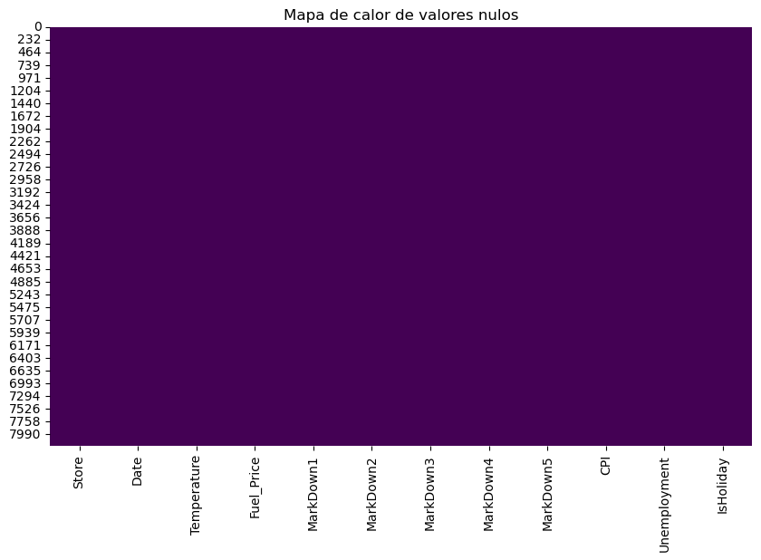

```python
# Check for null values in all columns.
print("Revisión de valores nulos:")
print(features_df.isnull().sum())

# Review duplicates in the DataFrame.
print("\nRevisión de filas duplicadas:")
print(features_df.duplicated().sum())

# Review the data types of each column.
print("\nTipos de datos en el DataFrame:")
print(features_df.dtypes)

# Generate descriptive statistics for the numerical columns.
print("\nEstadísticas descriptivas:")
print(features_df.describe())

# Visualize general information about the DataFrame.
print("\nInformación general del DataFrame:")
features_df.info()

import seaborn as sns
import matplotlib.pyplot as plt

# Generate a heatmap to visualize potential null value issues.
plt.figure(figsize=(10, 6))
sns.heatmap(features_df.isnull(), cbar=False, cmap='viridis')
plt.title("Mapa de calor de valores nulos")
plt.show()
```

## Final Conclusions

This process guarantees that the insights derived from the data will be accurate and trustworthy, enhancing the reliability of any further analysis.